# RBIF102 Week 2 Homework

Rita Pecuch

2024-10-20

## Question 1

Q1: What is the sequence ID of the closest Cryptosporidium parvum homolog?

By executing the below code, it can be determined that the sequence ID of the closest Cryptosporidium parvum homolog is cgd3_980-RA-p1. This is done by finding the sequence ID that is the highest percent identical to PfROM.

```r
# Read BLAST output file and rename columns
crypto <- read.table("/Users/ritapecuch/blast/db/Cparvum_blp.txt")
colnames(crypto) <- c("QueryAccesion", "SubjectAccession", "PercentIdentical", "length", "mismatch", "gapopen" , "Qstart", "Qend", "Sstart", "Send", "evalue", "bitscore")
# Get sequence ID of closet Cryptosporidium parvum homolog
max_percent_identical <- max(crypto$PercentIdentical)
seq_id <- crypto[crypto$PercentIdentical == max_percent_identical, "SubjectAccession"]
print(seq_id)
```

```
## [1] "cgd3_980-RA-p1"
```

## Question 2

Q2: What is the mean of the e-values?

By executing the below code, it can be determined that the mean of the e-values is 4.075e-13.

```r
# Get summary statistics
summary(crypto)
```

```
##  QueryAccesion      SubjectAccession   PercentIdentical     length
##  Length:12          Length:12          Min.   :26.95    Min.   :140.0
##  Class :character   Class :character   1st Qu.:29.08    1st Qu.:160.2
##  Mode  :character   Mode  :character   Median :31.49    Median :282.5
##                                        Mean   :31.70    Mean   :267.4
##                                        3rd Qu.:34.00    3rd Qu.:349.2
##                                        Max.   :37.85    Max.   :479.0
##     mismatch        gapopen           Qstart           Qend
##  Min.   : 79.0   Min.   : 1.000   Min.   :  1.0   Min.   :238.0
##  1st Qu.:103.5   1st Qu.: 3.000   1st Qu.:225.0   1st Qu.:379.8
##  Median :164.0   Median : 6.500   Median :310.5   Median :584.5
##  Mean   :150.7   Mean   : 6.917   Mean   :269.2   Mean   :518.5
##  3rd Qu.:191.5   3rd Qu.:10.000   3rd Qu.:345.2   3rd Qu.:651.2
##  Max.   :220.0   Max.   :17.000   Max.   :457.0   Max.   :755.0
##      Sstart           Send           evalue             bitscore
##  Min.   :  1.0   Min.   :228.0   Min.   :0.000e+00   Min.   : 63.50
##  1st Qu.: 92.0   1st Qu.:239.2   1st Qu.:0.000e+00   1st Qu.: 80.35
##  Median :157.5   Median :454.5   Median :0.000e+00   Median :135.00
##  Mean   :273.9   Mean   :524.3   Mean   :4.075e-13   Mean   :122.26
##  3rd Qu.:571.0   3rd Qu.:815.5   3rd Qu.:1.300e-16   3rd Qu.:169.25
##  Max.   :616.0   Max.   :972.0   Max.   :4.700e-12   Max.   :177.00
```

## Question 3

Q3: Are bitscore and alignment length correlated?

The below plot and correlation coefficient of approximately 0.85 demonstrate that bitscore and alignment length are positively correlated.

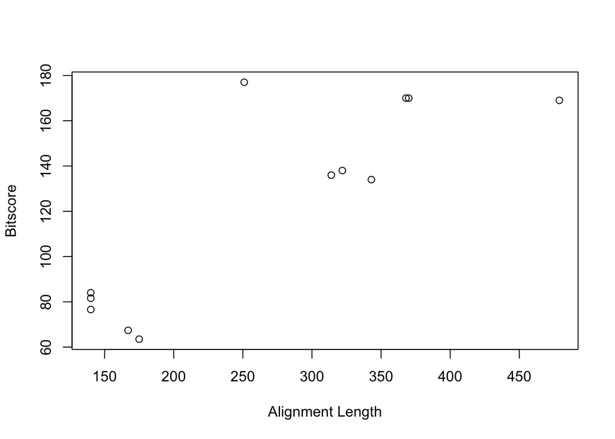

```r
# Plot relationship between bitscore and alignment length
plot(crypto$length, crypto$bitscore, xlab="Alignment Length", ylab="Bitscore")
```

```r
# Get correlation coefficient between bitscore and alignment length
cor(crypto$length, crypto$bitscore)
```

```
## [1] 0.8516511
```

## Bonus Question

Open the Rom.fa file and copy just the first sequence, P. Falciparum ROM4. Use the hmmscan tool to search this sequence for hmm domains. There should be a single domain found in this protein. What are the start and end positions of this domain?

The start position of this hidden Markov model (hmm) domain is 453 and the end position is 596.